# cyclistic_2023

Nurlybek Zhumabek

2024-11-28

##Introduction

This is my first capstone project from [Google Data Analytics Professional Certificate](https://www.coursera.org/professional-certificates/google-data-analytics) course.

##Purpose The goal of this project is to study how annual members and casual riders of a Cyclistic, bike-share company differ, and why casual riders would buy annual membership, and how digital media could affect marketing tactics. The project aims to design marketing strategies for converting casual riders to annual members.

##Scenario

You are a junior data analyst working in the marketing analyst team at Cyclistic, a bike-share company in Chicago. The director of marketing believes the company’s future success depends on maximizing the number of annual memberships. Therefore, your team wants to understand how casual riders and annual members use Cyclistic bikes differently. From these insights, your team will design a new marketing strategy to convert casual riders into annual members. But first, Cyclistic executives must approve your recommendations, so they must be backed up with compelling data insights and professional data visualizations.

**For this project following data analysis steps will be followed:** - Ask - Prepare - Process - Analyze - Share - Act

##Ask

**Three questions will guide the future marketing program:**

1. How do annual members and casual riders use Cyclistic bikes differently?
2. Why would casual riders buy Cyclistic annual memberships?
3. How can Cyclistic use digital media to influence casual riders to become members?

The director of marketing and your manager Lily Moreno has assigned you the first question to answer: How do annual members and casual riders use Cyclistic bikes differently?

**Key tasks**

- Identify the business task
  - The main objective is to build the best marketing strategies to turn casual bike riders into annual members by analyzing how the ‘Casual’ and ‘Annual’ customers use Cyclistic bike share differently.
- Consider key stakeholders
  - Cyclistic executive team, Director of Marketing (Lily Moreno), Marketing Analytics team.

**Deliverable**

- A clear statement of business task
  - The business problem is how we can maximize the number of annual memberships of the Cyclistic bike share company as defined by manager, Lily moreno. I was assigned to answer the question that states how annual members and casual riders use Cyclistic bikes differently, by a marketing analytics team. My findings regarding the following question will help to drive the decision making process of the executive team for planning for implementation.

##Prepare

**Key tasks**

- Download data and store it appropriately.
  - Data had been downloaded from link provided a and stored securely on my PC. Datasets are available [here.](https://divvy-tripdata.s3.amazonaws.com/index.html)
- Identify how it’s organized.
  - The dataset is organized by time, starting from recent to oldest data available. Each data is given as a .csv format file.
- Sort and filter the data.
  - For this analysis I’m going to use last 12 months data of the year 2023, as it’s the more current period to the business task.
- Determine the credibility of the data.
  - The current dataset is recognized as credible (ROCCC: Reliable, Original, Comprehensive, Current and Cited).

**Deliverable**

- A description of all data sources used
  - I used Cyclistic’s historical trip data to analyze and identify trends. The data has been made available by Motivate International Inc. under this [license](https://divvybikes.com/data-license-agreement).

##Process

For the analysis I will be using R programming language and RStudio IDE for it’s easy statistical analysis tools and data visualizations.

**Key tasks**

- Check the data for errors.
- Choose your tools.
- Transform the data so you can work with it effectively.
- Document the cleaning process.

**Deliverable**

- Documentation of any cleaning or manipulation of data
  - Please see following code chunks below

```r
## Open Rstudio by updated R version and install all relevant packages

library(tidyverse)
library(lubridate)
library(geosphere)
library(janitor)
library(ggmap)
## Import and download dataset available from the link provided

jan23 <- read_csv("D:/Downloads/202301-divvy-tripdata_Jan.csv")
feb23 <- read_csv("D:/Downloads/202302-divvy-tripdata_Feb.csv")
mar23 <- read_csv("D:/Downloads/202303-divvy-tripdata_Mar.csv")
apr23 <- read_csv("D:/Downloads/202304-divvy-tripdata_Apr.csv")
may23 <- read_csv("D:/Downloads/202305-divvy-tripdata_May.csv")
jun23 <- read_csv("D:/Downloads/202306-divvy-tripdata_Jun.csv")
jul23 <- read_csv("D:/Downloads/202307-divvy-tripdata_Jul.csv")
aug23 <- read_csv("D:/Downloads/202308-divvy-tripdata_Aug.csv")
sep23 <- read_csv("D:/Downloads/202309-divvy-tripdata_Sep.csv")
oct23 <- read_csv("D:/Downloads/202310-divvy-tripdata_Oct.csv")
nov23 <- read_csv("D:/Downloads/202311-divvy-tripdata_Nov.csv")
dec23 <- read_csv("D:/Downloads/202312-divvy-tripdata_Dec.csv")
## Check data for consistency

colnames(jan23)
```

```
##  [1] "ride_id"            "rideable_type"      "started_at"
##  [4] "ended_at"           "start_station_name" "start_station_id"
##  [7] "end_station_name"   "end_station_id"     "start_lat"
## [10] "start_lng"          "end_lat"            "end_lng"
## [13] "member_casual"
```

```r
colnames(feb23)
```

```
##  [1] "ride_id"            "rideable_type"      "started_at"
##  [4] "ended_at"           "start_station_name" "start_station_id"
##  [7] "end_station_name"   "end_station_id"     "start_lat"
## [10] "start_lng"          "end_lat"            "end_lng"
## [13] "member_casual"
```

```r
colnames(mar23)
```

```
##  [1] "ride_id"            "rideable_type"      "started_at"
##  [4] "ended_at"           "start_station_name" "start_station_id"
##  [7] "end_station_name"   "end_station_id"     "start_lat"
## [10] "start_lng"          "end_lat"            "end_lng"
## [13] "member_casual"
```

```r
colnames(apr23)
```

```
##  [1] "ride_id"            "rideable_type"      "started_at"
##  [4] "ended_at"           "start_station_name" "start_station_id"
##  [7] "end_station_name"   "end_station_id"     "start_lat"
## [10] "start_lng"          "end_lat"            "end_lng"
## [13] "member_casual"
```

```r
colnames(may23)
```

```
##  [1] "ride_id"            "rideable_type"      "started_at"
##  [4] "ended_at"           "start_station_name" "start_station_id"
##  [7] "end_station_name"   "end_station_id"     "start_lat"
## [10] "start_lng"          "end_lat"            "end_lng"
## [13] "member_casual"
```

```r
colnames(jun23)
```

```
##  [1] "ride_id"            "rideable_type"      "started_at"
##  [4] "ended_at"           "start_station_name" "start_station_id"
##  [7] "end_station_name"   "end_station_id"     "start_lat"
## [10] "start_lng"          "end_lat"            "end_lng"
## [13] "member_casual"
```

```r
colnames(jul23)
```

```
##  [1] "ride_id"            "rideable_type"      "started_at"
##  [4] "ended_at"           "start_station_name" "start_station_id"
##  [7] "end_station_name"   "end_station_id"     "start_lat"
## [10] "start_lng"          "end_lat"            "end_lng"
## [13] "member_casual"
```

```r
colnames(aug23)
```

```
##  [1] "ride_id"            "rideable_type"      "started_at"
##  [4] "ended_at"           "start_station_name" "start_station_id"
##  [7] "end_station_name"   "end_station_id"     "start_lat"
## [10] "start_lng"          "end_lat"            "end_lng"
## [13] "member_casual"
```

```r
colnames(sep23)
```

```
##  [1] "ride_id"            "rideable_type"      "started_at"
##  [4] "ended_at"           "start_station_name" "start_station_id"
##  [7] "end_station_name"   "end_station_id"     "start_lat"
## [10] "start_lng"          "end_lat"            "end_lng"
## [13] "member_casual"
```

```r
colnames(oct23)
```

```
##  [1] "ride_id"            "rideable_type"      "started_at"
##  [4] "ended_at"           "start_station_name" "start_station_id"
##  [7] "end_station_name"   "end_station_id"     "start_lat"
## [10] "start_lng"          "end_lat"            "end_lng"
## [13] "member_casual"
```

```r
colnames(nov23)
```

```
##  [1] "ride_id"            "rideable_type"      "started_at"
##  [4] "ended_at"           "start_station_name" "start_station_id"
##  [7] "end_station_name"   "end_station_id"     "start_lat"
## [10] "start_lng"          "end_lat"            "end_lng"
## [13] "member_casual"
```

```r
colnames(dec23)
```

```
##  [1] "ride_id"            "rideable_type"      "started_at"
##  [4] "ended_at"           "start_station_name" "start_station_id"
##  [7] "end_station_name"   "end_station_id"     "start_lat"
## [10] "start_lng"          "end_lat"            "end_lng"
## [13] "member_casual"
```

```r
## Check data stuctures
str(jan23)
```

```
## spc_tbl_ [190,301 × 13] (S3: spec_tbl_df/tbl_df/tbl/data.frame)
##  $ ride_id           : chr [1:190301] "F96D5A74A3E41399" "13CB7EB698CEDB88" "BD88A2E670661CE5" "C90792D034FED968" ...
##  $ rideable_type     : chr [1:190301] "electric_bike" "classic_bike" "electric_bike" "classic_bike" ...
##  $ started_at        : POSIXct[1:190301], format: "2023-01-21 20:05:42" "2023-01-10 15:37:36" ...
##  $ ended_at          : POSIXct[1:190301], format: "2023-01-21 20:16:33" "2023-01-10 15:46:05" ...
##  $ start_station_name: chr [1:190301] "Lincoln Ave & Fullerton Ave" "Kimbark Ave & 53rd St" "Western Ave & Lunt Ave" "Kimbark Ave & 53rd St" ...
##  $ start_station_id  : chr [1:190301] "TA1309000058" "TA1309000037" "RP-005" "TA1309000037" ...
##  $ end_station_name  : chr [1:190301] "Hampden Ct & Diversey Ave" "Greenwood Ave & 47th St" "Valli Produce - Evanston Plaza" "Greenwood Ave & 47th St" ...
##  $ end_station_id    : chr [1:190301] "202480.0" "TA1308000002" "599" "TA1308000002" ...
##  $ start_lat         : num [1:190301] 41.9 41.8 42 41.8 41.8 ...
##  $ start_lng         : num [1:190301] -87.6 -87.6 -87.7 -87.6 -87.6 ...
##  $ end_lat           : num [1:190301] 41.9 41.8 42 41.8 41.8 ...
##  $ end_lng           : num [1:190301] -87.6 -87.6 -87.7 -87.6 -87.6 ...
##  $ member_casual     : chr [1:190301] "member" "member" "casual" "member" ...
##  - attr(*, "spec")=
##   .. cols(
##   ..   ride_id = col_character(),
##   ..   rideable_type = col_character(),
##   ..   started_at = col_datetime(format = ""),
##   ..   ended_at = col_datetime(format = ""),
##   ..   start_station_name = col_character(),
##   ..   start_station_id = col_character(),
##   ..   end_station_name = col_character(),
##   ..   end_station_id = col_character(),
##   ..   start_lat = col_double(),
##   ..   start_lng = col_double(),
##   ..   end_lat = col_double(),
##   ..   end_lng = col_double(),
##   ..   member_casual = col_character()
##   .. )
##  - attr(*, "problems")=<externalptr>
```

```r
str(feb23)
```

```
## spc_tbl_ [190,445 × 13] (S3: spec_tbl_df/tbl_df/tbl/data.frame)
##  $ ride_id           : chr [1:190445] "CBCD0D7777F0E45F" "F3EC5FCE5FF39DE9" "E54C1F27FA9354FF" "3D561E04F739CC45" ...
##  $ rideable_type     : chr [1:190445] "classic_bike" "electric_bike" "classic_bike" "electric_bike" ...
##  $ started_at        : POSIXct[1:190445], format: "2023-02-14 11:59:42" "2023-02-15 13:53:48" ...
##  $ ended_at          : POSIXct[1:190445], format: "2023-02-14 12:13:38" "2023-02-15 13:59:08" ...
##  $ start_station_name: chr [1:190445] "Southport Ave & Clybourn Ave" "Clarendon Ave & Gordon Ter" "Southport Ave & Clybourn Ave" "Southport Ave & Clybourn Ave" ...
##  $ start_station_id  : chr [1:190445] "TA1309000030" "13379" "TA1309000030" "TA1309000030" ...
##  $ end_station_name  : chr [1:190445] "Clark St & Schiller St" "Sheridan Rd & Lawrence Ave" "Aberdeen St & Monroe St" "Franklin St & Adams St (Temp)" ...
##  $ end_station_id    : chr [1:190445] "TA1309000024" "TA1309000041" "13156" "TA1309000008" ...
##  $ start_lat         : num [1:190445] 41.9 42 41.9 41.9 41.8 ...
##  $ start_lng         : num [1:190445] -87.7 -87.6 -87.7 -87.7 -87.6 ...
##  $ end_lat           : num [1:190445] 41.9 42 41.9 41.9 41.8 ...
##  $ end_lng           : num [1:190445] -87.6 -87.7 -87.7 -87.6 -87.6 ...
##  $ member_casual     : chr [1:190445] "casual" "casual" "member" "member" ...
##  - attr(*, "spec")=
##   .. cols(
##   ..   ride_id = col_character(),
##   ..   rideable_type = col_character(),
##   ..   started_at = col_datetime(format = ""),
##   ..   ended_at = col_datetime(format = ""),
##   ..   start_station_name = col_character(),
##   ..   start_station_id = col_character(),
##   ..   end_station_name = col_character(),
##   ..   end_station_id = col_character(),
##   ..   start_lat = col_double(),
##   ..   start_lng = col_double(),
##   ..   end_lat = col_double(),
##   ..   end_lng = col_double(),
##   ..   member_casual = col_character()
##   .. )
##  - attr(*, "problems")=<externalptr>
```

```r
str(mar23)
```

```
## spc_tbl_ [258,678 × 13] (S3: spec_tbl_df/tbl_df/tbl/data.frame)
##  $ ride_id           : chr [1:258678] "6842AA605EE9FBB3" "F984267A75B99A8C" "FF7CF57CFE026D02" "6B61B916032CB6D6" ...
##  $ rideable_type     : chr [1:258678] "electric_bike" "electric_bike" "classic_bike" "classic_bike" ...
##  $ started_at        : POSIXct[1:258678], format: "2023-03-16 08:20:34" "2023-03-04 14:07:06" ...
##  $ ended_at          : POSIXct[1:258678], format: "2023-03-16 08:22:52" "2023-03-04 14:15:31" ...
##  $ start_station_name: chr [1:258678] "Clark St & Armitage Ave" "Public Rack - Kedzie Ave & Argyle St" "Orleans St & Chestnut St (NEXT Apts)" "Desplaines St & Kinzie St" ...
##  $ start_station_id  : chr [1:258678] "13146" "491" "620" "TA1306000003" ...
##  $ end_station_name  : chr [1:258678] "Larrabee St & Webster Ave" NA "Clark St & Randolph St" "Sheffield Ave & Kingsbury St" ...
##  $ end_station_id    : chr [1:258678] "13193" NA "TA1305000030" "13154" ...
##  $ start_lat         : num [1:258678] 41.9 42 41.9 41.9 41.9 ...
##  $ start_lng         : num [1:258678] -87.6 -87.7 -87.6 -87.6 -87.7 ...
##  $ end_lat           : num [1:258678] 41.9 42 41.9 41.9 41.9 ...
##  $ end_lng           : num [1:258678] -87.6 -87.7 -87.6 -87.7 -87.7 ...
##  $ member_casual     : chr [1:258678] "member" "member" "member" "member" ...
##  - attr(*, "spec")=
##   .. cols(
##   ..   ride_id = col_character(),
##   ..   rideable_type = col_character(),
##   ..   started_at = col_datetime(format = ""),
##   ..   ended_at = col_datetime(format = ""),
##   ..   start_station_name = col_character(),
##   ..   start_station_id = col_character(),
##   ..   end_station_name = col_character(),
##   ..   end_station_id = col_character(),
##   ..   start_lat = col_double(),
##   ..   start_lng = col_double(),
##   ..   end_lat = col_double(),
##   ..   end_lng = col_double(),
##   ..   member_casual = col_character()
##   .. )
##  - attr(*, "problems")=<externalptr>
```

```r
str(apr23)
```

```
## spc_tbl_ [426,590 × 13] (S3: spec_tbl_df/tbl_df/tbl/data.frame)
##  $ ride_id           : chr [1:426590] "8FE8F7D9C10E88C7" "34E4ED3ADF1D821B" "5296BF07A2F77CB5" "40759916B76D5D52" ...
##  $ rideable_type     : chr [1:426590] "electric_bike" "electric_bike" "electric_bike" "electric_bike" ...
##  $ started_at        : POSIXct[1:426590], format: "2023-04-02 08:37:28" "2023-04-19 11:29:02" ...
##  $ ended_at          : POSIXct[1:426590], format: "2023-04-02 08:41:37" "2023-04-19 11:52:12" ...
##  $ start_station_name: chr [1:426590] NA NA NA NA ...
##  $ start_station_id  : chr [1:426590] NA NA NA NA ...
##  $ end_station_name  : chr [1:426590] NA NA NA NA ...
##  $ end_station_id    : chr [1:426590] NA NA NA NA ...
##  $ start_lat         : num [1:426590] 41.8 41.9 41.9 41.9 41.9 ...
##  $ start_lng         : num [1:426590] -87.6 -87.7 -87.7 -87.7 -87.7 ...
##  $ end_lat           : num [1:426590] 41.8 41.9 41.9 41.9 41.9 ...
##  $ end_lng           : num [1:426590] -87.6 -87.7 -87.7 -87.7 -87.6 ...
##  $ member_casual     : chr [1:426590] "member" "member" "member" "member" ...
##  - attr(*, "spec")=
##   .. cols(
##   ..   ride_id = col_character(),
##   ..   rideable_type = col_character(),
##   ..   started_at = col_datetime(format = ""),
##   ..   ended_at = col_datetime(format = ""),
##   ..   start_station_name = col_character(),
##   ..   start_station_id = col_character(),
##   ..   end_station_name = col_character(),
##   ..   end_station_id = col_character(),
##   ..   start_lat = col_double(),
##   ..   start_lng = col_double(),
##   ..   end_lat = col_double(),
##   ..   end_lng = col_double(),
##   ..   member_casual = col_character()
##   .. )
##  - attr(*, "problems")=<externalptr>
```

```r
str(may23)
```

```
## spc_tbl_ [604,827 × 13] (S3: spec_tbl_df/tbl_df/tbl/data.frame)
##  $ ride_id           : chr [1:604827] "0D9FA920C3062031" "92485E5FB5888ACD" "FB144B3FC8300187" "DDEB93BC2CE9AA77" ...
##  $ rideable_type     : chr [1:604827] "electric_bike" "electric_bike" "electric_bike" "classic_bike" ...
##  $ started_at        : POSIXct[1:604827], format: "2023-05-07 19:53:48" "2023-05-06 18:54:08" ...
##  $ ended_at          : POSIXct[1:604827], format: "2023-05-07 19:58:32" "2023-05-06 19:03:35" ...
##  $ start_station_name: chr [1:604827] "Southport Ave & Belmont Ave" "Southport Ave & Belmont Ave" "Halsted St & 21st St" "Carpenter St & Huron St" ...
##  $ start_station_id  : chr [1:604827] "13229" "13229" "13162" "13196" ...
##  $ end_station_name  : chr [1:604827] NA NA NA "Damen Ave & Cortland St" ...
##  $ end_station_id    : chr [1:604827] NA NA NA "13133" ...
##  $ start_lat         : num [1:604827] 41.9 41.9 41.9 41.9 42 ...
##  $ start_lng         : num [1:604827] -87.7 -87.7 -87.6 -87.7 -87.7 ...
##  $ end_lat           : num [1:604827] 41.9 41.9 41.9 41.9 41.9 ...
##  $ end_lng           : num [1:604827] -87.7 -87.7 -87.7 -87.7 -87.7 ...
##  $ member_casual     : chr [1:604827] "member" "member" "member" "member" ...
##  - attr(*, "spec")=
##   .. cols(
##   ..   ride_id = col_character(),
##   ..   rideable_type = col_character(),
##   ..   started_at = col_datetime(format = ""),
##   ..   ended_at = col_datetime(format = ""),
##   ..   start_station_name = col_character(),
##   ..   start_station_id = col_character(),
##   ..   end_station_name = col_character(),
##   ..   end_station_id = col_character(),
##   ..   start_lat = col_double(),
##   ..   start_lng = col_double(),
##   ..   end_lat = col_double(),
##   ..   end_lng = col_double(),
##   ..   member_casual = col_character()
##   .. )
##  - attr(*, "problems")=<externalptr>
```

```r
str(jun23)
```

```
## spc_tbl_ [719,618 × 13] (S3: spec_tbl_df/tbl_df/tbl/data.frame)
##  $ ride_id           : chr [1:719618] "6F1682AC40EB6F71" "622A1686D64948EB" "3C88859D926253B4" "EAD8A5E0259DEC88" ...
##  $ rideable_type     : chr [1:719618] "electric_bike" "electric_bike" "electric_bike" "electric_bike" ...
##  $ started_at        : POSIXct[1:719618], format: "2023-06-05 13:34:12" "2023-06-05 01:30:22" ...
##  $ ended_at          : POSIXct[1:719618], format: "2023-06-05 14:31:56" "2023-06-05 01:33:06" ...
##  $ start_station_name: chr [1:719618] NA NA NA NA ...
##  $ start_station_id  : chr [1:719618] NA NA NA NA ...
##  $ end_station_name  : chr [1:719618] NA NA NA NA ...
##  $ end_station_id    : chr [1:719618] NA NA NA NA ...
##  $ start_lat         : num [1:719618] 41.9 41.9 42 42 42 ...
##  $ start_lng         : num [1:719618] -87.7 -87.7 -87.7 -87.7 -87.7 ...
##  $ end_lat           : num [1:719618] 41.9 41.9 41.9 42 42 ...
##  $ end_lng           : num [1:719618] -87.7 -87.7 -87.6 -87.7 -87.7 ...
##  $ member_casual     : chr [1:719618] "member" "member" "member" "member" ...
##  - attr(*, "spec")=
##   .. cols(
##   ..   ride_id = col_character(),
##   ..   rideable_type = col_character(),
##   ..   started_at = col_datetime(format = ""),
##   ..   ended_at = col_datetime(format = ""),
##   ..   start_station_name = col_character(),
##   ..   start_station_id = col_character(),
##   ..   end_station_name = col_character(),
##   ..   end_station_id = col_character(),
##   ..   start_lat = col_double(),
##   ..   start_lng = col_double(),
##   ..   end_lat = col_double(),
##   ..   end_lng = col_double(),
##   ..   member_casual = col_character()
##   .. )
##  - attr(*, "problems")=<externalptr>
```

```r
str(jul23)
```

```
## spc_tbl_ [767,650 × 13] (S3: spec_tbl_df/tbl_df/tbl/data.frame)
##  $ ride_id           : chr [1:767650] "9340B064F0AEE130" "D1460EE3CE0D8AF8" "DF41BE31B895A25E" "9624A293749EF703" ...
##  $ rideable_type     : chr [1:767650] "electric_bike" "classic_bike" "classic_bike" "electric_bike" ...
##  $ started_at        : POSIXct[1:767650], format: "2023-07-23 20:06:14" "2023-07-23 17:05:07" ...
##  $ ended_at          : POSIXct[1:767650], format: "2023-07-23 20:22:44" "2023-07-23 17:18:37" ...
##  $ start_station_name: chr [1:767650] "Kedzie Ave & 110th St" "Western Ave & Walton St" "Western Ave & Walton St" "Racine Ave & Randolph St" ...
##  $ start_station_id  : chr [1:767650] "20204" "KA1504000103" "KA1504000103" "13155" ...
##  $ end_station_name  : chr [1:767650] "Public Rack - Racine Ave & 109th Pl" "Milwaukee Ave & Grand Ave" "Damen Ave & Pierce Ave" "Clinton St & Madison St" ...
##  $ end_station_id    : chr [1:767650] "877" "13033" "TA1305000041" "TA1305000032" ...
##  $ start_lat         : num [1:767650] 41.7 41.9 41.9 41.9 42 ...
##  $ start_lng         : num [1:767650] -87.7 -87.7 -87.7 -87.7 -87.7 ...
##  $ end_lat           : num [1:767650] 41.7 41.9 41.9 41.9 42 ...
##  $ end_lng           : num [1:767650] -87.7 -87.6 -87.7 -87.6 -87.6 ...
##  $ member_casual     : chr [1:767650] "member" "member" "member" "member" ...
##  - attr(*, "spec")=
##   .. cols(
##   ..   ride_id = col_character(),
##   ..   rideable_type = col_character(),
##   ..   started_at = col_datetime(format = ""),
##   ..   ended_at = col_datetime(format = ""),
##   ..   start_station_name = col_character(),
##   ..   start_station_id = col_character(),
##   ..   end_station_name = col_character(),
##   ..   end_station_id = col_character(),
##   ..   start_lat = col_double(),
##   ..   start_lng = col_double(),
##   ..   end_lat = col_double(),
##   ..   end_lng = col_double(),
##   ..   member_casual = col_character()
##   .. )
##  - attr(*, "problems")=<externalptr>
```

```r
str(aug23)
```

```
## spc_tbl_ [771,693 × 13] (S3: spec_tbl_df/tbl_df/tbl/data.frame)
##  $ ride_id           : chr [1:771693] "903C30C2D810A53B" "F2FB18A98E110A2B" "D0DEC7C94E4663DA" "E0DDDC5F84747ED9" ...
##  $ rideable_type     : chr [1:771693] "electric_bike" "electric_bike" "electric_bike" "electric_bike" ...
##  $ started_at        : POSIXct[1:771693], format: "2023-08-19 15:41:53" "2023-08-18 15:30:18" ...
##  $ ended_at          : POSIXct[1:771693], format: "2023-08-19 15:53:36" "2023-08-18 15:45:25" ...
##  $ start_station_name: chr [1:771693] "LaSalle St & Illinois St" "Clark St & Randolph St" "Clark St & Randolph St" "Wells St & Elm St" ...
##  $ start_station_id  : chr [1:771693] "13430" "TA1305000030" "TA1305000030" "KA1504000135" ...
##  $ end_station_name  : chr [1:771693] "Clark St & Elm St" NA NA NA ...
##  $ end_station_id    : chr [1:771693] "TA1307000039" NA NA NA ...
##  $ start_lat         : num [1:771693] 41.9 41.9 41.9 41.9 41.9 ...
##  $ start_lng         : num [1:771693] -87.6 -87.6 -87.6 -87.6 -87.6 ...
##  $ end_lat           : num [1:771693] 41.9 41.9 41.9 41.9 41.9 ...
##  $ end_lng           : num [1:771693] -87.6 -87.6 -87.6 -87.6 -87.7 ...
##  $ member_casual     : chr [1:771693] "member" "member" "member" "member" ...
##  - attr(*, "spec")=
##   .. cols(
##   ..   ride_id = col_character(),
##   ..   rideable_type = col_character(),
##   ..   started_at = col_datetime(format = ""),
##   ..   ended_at = col_datetime(format = ""),
##   ..   start_station_name = col_character(),
##   ..   start_station_id = col_character(),
##   ..   end_station_name = col_character(),
##   ..   end_station_id = col_character(),
##   ..   start_lat = col_double(),
##   ..   start_lng = col_double(),
##   ..   end_lat = col_double(),
##   ..   end_lng = col_double(),
##   ..   member_casual = col_character()
##   .. )
##  - attr(*, "problems")=<externalptr>
```

```r
str(sep23)
```

```
## spc_tbl_ [666,371 × 13] (S3: spec_tbl_df/tbl_df/tbl/data.frame)
##  $ ride_id           : chr [1:666371] "011C1903BF4E2E28" "87DB80E048A1BF9F" "7C2EB7AF669066E3" "57D197B010269CE3" ...
##  $ rideable_type     : chr [1:666371] "classic_bike" "classic_bike" "electric_bike" "classic_bike" ...
##  $ started_at        : POSIXct[1:666371], format: "2023-09-23 00:27:50" "2023-09-02 09:26:43" ...
##  $ ended_at          : POSIXct[1:666371], format: "2023-09-23 00:33:27" "2023-09-02 09:38:19" ...
##  $ start_station_name: chr [1:666371] "Halsted St & Wrightwood Ave" "Clark St & Drummond Pl" "Financial Pl & Ida B Wells Dr" "Clark St & Drummond Pl" ...
##  $ start_station_id  : chr [1:666371] "TA1309000061" "TA1307000142" "SL-010" "TA1307000142" ...
##  $ end_station_name  : chr [1:666371] "Sheffield Ave & Wellington Ave" "Racine Ave & Fullerton Ave" "Racine Ave & 15th St" "Racine Ave & Belmont Ave" ...
##  $ end_station_id    : chr [1:666371] "TA1307000052" "TA1306000026" "13304" "TA1308000019" ...
##  $ start_lat         : num [1:666371] 41.9 41.9 41.9 41.9 41.9 ...
##  $ start_lng         : num [1:666371] -87.6 -87.6 -87.6 -87.6 -87.6 ...
##  $ end_lat           : num [1:666371] 41.9 41.9 41.9 41.9 41.9 ...
##  $ end_lng           : num [1:666371] -87.7 -87.7 -87.7 -87.7 -87.7 ...
##  $ member_casual     : chr [1:666371] "member" "member" "member" "member" ...
##  - attr(*, "spec")=
##   .. cols(
##   ..   ride_id = col_character(),
##   ..   rideable_type = col_character(),
##   ..   started_at = col_datetime(format = ""),
##   ..   ended_at = col_datetime(format = ""),
##   ..   start_station_name = col_character(),
##   ..   start_station_id = col_character(),
##   ..   end_station_name = col_character(),
##   ..   end_station_id = col_character(),
##   ..   start_lat = col_double(),
##   ..   start_lng = col_double(),
##   ..   end_lat = col_double(),
##   ..   end_lng = col_double(),
##   ..   member_casual = col_character()
##   .. )
##  - attr(*, "problems")=<externalptr>
```

```r
str(oct23)
```

```
## spc_tbl_ [537,113 × 13] (S3: spec_tbl_df/tbl_df/tbl/data.frame)
##  $ ride_id           : chr [1:537113] "4449097279F8BBE7" "9CF060543CA7B439" "667F21F4D6BDE69C" "F92714CC6B019B96" ...
##  $ rideable_type     : chr [1:537113] "classic_bike" "electric_bike" "electric_bike" "classic_bike" ...
##  $ started_at        : POSIXct[1:537113], format: "2023-10-08 10:36:26" "2023-10-11 17:23:59" ...
##  $ ended_at          : POSIXct[1:537113], format: "2023-10-08 10:49:19" "2023-10-11 17:36:08" ...
##  $ start_station_name: chr [1:537113] "Orleans St & Chestnut St (NEXT Apts)" "Desplaines St & Kinzie St" "Orleans St & Chestnut St (NEXT Apts)" "Desplaines St & Kinzie St" ...
##  $ start_station_id  : chr [1:537113] "620" "TA1306000003" "620" "TA1306000003" ...
##  $ end_station_name  : chr [1:537113] "Sheffield Ave & Webster Ave" "Sheffield Ave & Webster Ave" "Franklin St & Lake St" "Franklin St & Lake St" ...
##  $ end_station_id    : chr [1:537113] "TA1309000033" "TA1309000033" "TA1307000111" "TA1307000111" ...
##  $ start_lat         : num [1:537113] 41.9 41.9 41.9 41.9 41.9 ...
##  $ start_lng         : num [1:537113] -87.6 -87.6 -87.6 -87.6 -87.6 ...
##  $ end_lat           : num [1:537113] 41.9 41.9 41.9 41.9 41.9 ...
##  $ end_lng           : num [1:537113] -87.7 -87.7 -87.6 -87.6 -87.6 ...
##  $ member_casual     : chr [1:537113] "member" "member" "member" "member" ...
##  - attr(*, "spec")=
##   .. cols(
##   ..   ride_id = col_character(),
##   ..   rideable_type = col_character(),
##   ..   started_at = col_datetime(format = ""),
##   ..   ended_at = col_datetime(format = ""),
##   ..   start_station_name = col_character(),
##   ..   start_station_id = col_character(),
##   ..   end_station_name = col_character(),
##   ..   end_station_id = col_character(),
##   ..   start_lat = col_double(),
##   ..   start_lng = col_double(),
##   ..   end_lat = col_double(),
##   ..   end_lng = col_double(),
##   ..   member_casual = col_character()
##   .. )
##  - attr(*, "problems")=<externalptr>
```

```r
str(nov23)
```

```
## spc_tbl_ [362,518 × 13] (S3: spec_tbl_df/tbl_df/tbl/data.frame)
##  $ ride_id           : chr [1:362518] "4EAD8F1AD547356B" "6322270563BF5470" "B37BDE091ECA38E0" "CF0CA5DD26E4F90E" ...
##  $ rideable_type     : chr [1:362518] "electric_bike" "electric_bike" "electric_bike" "classic_bike" ...
##  $ started_at        : POSIXct[1:362518], format: "2023-11-30 21:50:05" "2023-11-03 09:44:02" ...
##  $ ended_at          : POSIXct[1:362518], format: "2023-11-30 22:13:27" "2023-11-03 10:17:15" ...
##  $ start_station_name: chr [1:362518] "Millennium Park" "Broadway & Sheridan Rd" "State St & Pearson St" "Theater on the Lake" ...
##  $ start_station_id  : chr [1:362518] "13008" "13323" "TA1307000061" "TA1308000001" ...
##  $ end_station_name  : chr [1:362518] "Pine Grove Ave & Waveland Ave" "Broadway & Sheridan Rd" "State St & Pearson St" "Theater on the Lake" ...
##  $ end_station_id    : chr [1:362518] "TA1307000150" "13323" "TA1307000061" "TA1308000001" ...
##  $ start_lat         : num [1:362518] 41.9 42 41.9 41.9 41.9 ...
##  $ start_lng         : num [1:362518] -87.6 -87.7 -87.6 -87.6 -87.6 ...
##  $ end_lat           : num [1:362518] 41.9 42 41.9 41.9 41.9 ...
##  $ end_lng           : num [1:362518] -87.6 -87.6 -87.6 -87.6 -87.6 ...
##  $ member_casual     : chr [1:362518] "member" "member" "member" "member" ...
##  - attr(*, "spec")=
##   .. cols(
##   ..   ride_id = col_character(),
##   ..   rideable_type = col_character(),
##   ..   started_at = col_datetime(format = ""),
##   ..   ended_at = col_datetime(format = ""),
##   ..   start_station_name = col_character(),
##   ..   start_station_id = col_character(),
##   ..   end_station_name = col_character(),
##   ..   end_station_id = col_character(),
##   ..   start_lat = col_double(),
##   ..   start_lng = col_double(),
##   ..   end_lat = col_double(),
##   ..   end_lng = col_double(),
##   ..   member_casual = col_character()
##   .. )
##  - attr(*, "problems")=<externalptr>
```

```r
str(dec23)
```

```
## spc_tbl_ [224,073 × 13] (S3: spec_tbl_df/tbl_df/tbl/data.frame)
##  $ ride_id           : chr [1:224073] "C9BD54F578F57246" "CDBD92F067FA620E" "ABC0858E52CBFC84" "F44B6F0E8F76DC90" ...
##  $ rideable_type     : chr [1:224073] "electric_bike" "electric_bike" "electric_bike" "electric_bike" ...
##  $ started_at        : POSIXct[1:224073], format: "2023-12-02 18:44:01" "2023-12-02 18:48:19" ...
##  $ ended_at          : POSIXct[1:224073], format: "2023-12-02 18:47:51" "2023-12-02 18:54:48" ...
##  $ start_station_name: chr [1:224073] NA NA NA NA ...
##  $ start_station_id  : chr [1:224073] NA NA NA NA ...
##  $ end_station_name  : chr [1:224073] NA NA NA NA ...
##  $ end_station_id    : chr [1:224073] NA NA NA NA ...
##  $ start_lat         : num [1:224073] 41.9 41.9 41.9 42 41.9 ...
##  $ start_lng         : num [1:224073] -87.7 -87.7 -87.6 -87.7 -87.6 ...
##  $ end_lat           : num [1:224073] 41.9 41.9 41.9 41.9 41.9 ...
##  $ end_lng           : num [1:224073] -87.7 -87.6 -87.6 -87.7 -87.6 ...
##  $ member_casual     : chr [1:224073] "member" "member" "member" "member" ...
##  - attr(*, "spec")=
##   .. cols(
##   ..   ride_id = col_character(),
##   ..   rideable_type = col_character(),
##   ..   started_at = col_datetime(format = ""),
##   ..   ended_at = col_datetime(format = ""),
##   ..   start_station_name = col_character(),
##   ..   start_station_id = col_character(),
##   ..   end_station_name = col_character(),
##   ..   end_station_id = col_character(),
##   ..   start_lat = col_double(),
##   ..   start_lng = col_double(),
##   ..   end_lat = col_double(),
##   ..   end_lng = col_double(),
##   ..   member_casual = col_character()
##   .. )
##  - attr(*, "problems")=<externalptr>
```

```r
## Merging individual monthly datasets into one data frame

tripdata23 <- bind_rows(jan23,feb23,mar23,apr23,may23,jun23,jul23,aug23,sep23,oct23,nov23,dec23)
```

```r
## Check merged data frame

colnames(tripdata23)
```

```
##  [1] "ride_id"            "rideable_type"      "started_at"
##  [4] "ended_at"           "start_station_name" "start_station_id"
##  [7] "end_station_name"   "end_station_id"     "start_lat"
## [10] "start_lng"          "end_lat"            "end_lng"
## [13] "member_casual"
```

```r
head(tripdata23)
```

```
## # A tibble: 6 × 13
##   ride_id          rideable_type started_at          ended_at
##   <chr>            <chr>         <dttm>              <dttm>
## 1 F96D5A74A3E41399 electric_bike 2023-01-21 20:05:42 2023-01-21 20:16:33
## 2 13CB7EB698CEDB88 classic_bike  2023-01-10 15:37:36 2023-01-10 15:46:05
## 3 BD88A2E670661CE5 electric_bike 2023-01-02 07:51:57 2023-01-02 08:05:11
## 4 C90792D034FED968 classic_bike  2023-01-22 10:52:58 2023-01-22 11:01:44
## 5 3397017529188E8A classic_bike  2023-01-12 13:58:01 2023-01-12 14:13:20
## 6 58E68156DAE3E311 electric_bike 2023-01-31 07:18:03 2023-01-31 07:21:16
## # ℹ 9 more variables: start_station_name <chr>, start_station_id <chr>,
## #   end_station_name <chr>, end_station_id <chr>, start_lat <dbl>,
## #   start_lng <dbl>, end_lat <dbl>, end_lng <dbl>, member_casual <chr>
```

```r
str(tripdata23)
```

```
## spc_tbl_ [5,719,877 × 13] (S3: spec_tbl_df/tbl_df/tbl/data.frame)
##  $ ride_id           : chr [1:5719877] "F96D5A74A3E41399" "13CB7EB698CEDB88" "BD88A2E670661CE5" "C90792D034FED968" ...
##  $ rideable_type     : chr [1:5719877] "electric_bike" "classic_bike" "electric_bike" "classic_bike" ...
##  $ started_at        : POSIXct[1:5719877], format: "2023-01-21 20:05:42" "2023-01-10 15:37:36" ...
##  $ ended_at          : POSIXct[1:5719877], format: "2023-01-21 20:16:33" "2023-01-10 15:46:05" ...
##  $ start_station_name: chr [1:5719877] "Lincoln Ave & Fullerton Ave" "Kimbark Ave & 53rd St" "Western Ave & Lunt Ave" "Kimbark Ave & 53rd St" ...
##  $ start_station_id  : chr [1:5719877] "TA1309000058" "TA1309000037" "RP-005" "TA1309000037" ...
##  $ end_station_name  : chr [1:5719877] "Hampden Ct & Diversey Ave" "Greenwood Ave & 47th St" "Valli Produce - Evanston Plaza" "Greenwood Ave & 47th St" ...
##  $ end_station_id    : chr [1:5719877] "202480.0" "TA1308000002" "599" "TA1308000002" ...
##  $ start_lat         : num [1:5719877] 41.9 41.8 42 41.8 41.8 ...
##  $ start_lng         : num [1:5719877] -87.6 -87.6 -87.7 -87.6 -87.6 ...
##  $ end_lat           : num [1:5719877] 41.9 41.8 42 41.8 41.8 ...
##  $ end_lng           : num [1:5719877] -87.6 -87.6 -87.7 -87.6 -87.6 ...
##  $ member_casual     : chr [1:5719877] "member" "member" "casual" "member" ...
##  - attr(*, "spec")=
##   .. cols(
##   ..   ride_id = col_character(),
##   ..   rideable_type = col_character(),
##   ..   started_at = col_datetime(format = ""),
##   ..   ended_at = col_datetime(format = ""),
##   ..   start_station_name = col_character(),
##   ..   start_station_id = col_character(),
##   ..   end_station_name = col_character(),
##   ..   end_station_id = col_character(),
##   ..   start_lat = col_double(),
##   ..   start_lng = col_double(),
##   ..   end_lat = col_double(),
##   ..   end_lng = col_double(),
##   ..   member_casual = col_character()
##   .. )
##  - attr(*, "problems")=<externalptr>
```

```r
summary(tripdata23)
```

```
##    ride_id          rideable_type        started_at
##  Length:5719877     Length:5719877     Min.   :2023-01-01 00:01:58.00
##  Class :character   Class :character   1st Qu.:2023-05-21 12:50:44.00
##  Mode  :character   Mode  :character   Median :2023-07-20 18:02:50.00
##                                        Mean   :2023-07-16 10:27:50.01
##                                        3rd Qu.:2023-09-16 20:08:49.00
##                                        Max.   :2023-12-31 23:59:38.00
##
##     ended_at                      start_station_name start_station_id
##  Min.   :2023-01-01 00:02:41.00   Length:5719877     Length:5719877
##  1st Qu.:2023-05-21 13:14:09.00   Class :character   Class :character
##  Median :2023-07-20 18:19:47.00   Mode  :character   Mode  :character
##  Mean   :2023-07-16 10:46:00.18
##  3rd Qu.:2023-09-16 20:28:10.00
##  Max.   :2024-01-01 23:50:51.00
##
##  end_station_name   end_station_id       start_lat       start_lng
##  Length:5719877     Length:5719877     Min.   :41.63   Min.   :-87.94
##  Class :character   Class :character   1st Qu.:41.88   1st Qu.:-87.66
##  Mode  :character   Mode  :character   Median :41.90   Median :-87.64
##                                        Mean   :41.90   Mean   :-87.65
##                                        3rd Qu.:41.93   3rd Qu.:-87.63
##                                        Max.   :42.07   Max.   :-87.46
##
##     end_lat         end_lng       member_casual
##  Min.   : 0.00   Min.   :-88.16   Length:5719877
##  1st Qu.:41.88   1st Qu.:-87.66   Class :character
##  Median :41.90   Median :-87.64   Mode  :character
##  Mean   :41.90   Mean   :-87.65
##  3rd Qu.:41.93   3rd Qu.:-87.63
##  Max.   :42.18   Max.   :  0.00
##  NA's   :6990    NA's   :6990
```

```r
## Adding date, month, year, day of week columns

tripdata23 <- tripdata23 %>%
mutate(year=format(as.Date(started_at),"%Y")) %>% # produce year
mutate(month=format(as.Date(started_at),"%B")) %>% # produce month
mutate(date=format(as.Date(started_at),"%d")) %>% # produce date
mutate(day_of_week=format(as.Date(started_at),"%A")) %>% # produce day of week
mutate(ride_length=difftime(ended_at,started_at)) %>%
mutate(start_time=strftime(started_at, "%H"))

## Converting “ride_length” to numeric data type for calculation

tripdata23 <- tripdata23 %>% mutate(ride_length=as.numeric(ride_length))

is.numeric(tripdata23$ride_length) # recheck
```

```
## [1] TRUE
```

```r
## Adding ride distance in km

tripdata23$ride_distance <- distGeo(matrix(c(tripdata23$start_lng,tripdata23$start_lat),ncol = 2),matrix(c(tripdata23$end_lng,tripdata23$end_lat),ncol = 2))

tripdata23$ride_distance <- tripdata23$ride_distance/1000 #distance in km
```

```r
## Data cleaning procedures

colSums(is.na(tripdata23)) # check for na values
```

```
##            ride_id      rideable_type         started_at           ended_at
##                  0                  0                  0                  0
## start_station_name   start_station_id   end_station_name     end_station_id
##             875716             875848             929202             929343
##          start_lat          start_lng            end_lat            end_lng
##                  0                  0               6990               6990
##      member_casual               year              month               date
##                  0                  0                  0                  0
##        day_of_week        ride_length         start_time      ride_distance
##                  0                  0                  0               6990
```

```r
tripdata23_cln1 <- tripdata23[!is.na(tripdata23$end_lat),] #remove na values in “eng_lat”

colSums(is.na(tripdata23_cln1)) # created new cleaned data frame and rechecked
```

```
##            ride_id      rideable_type         started_at           ended_at
##                  0                  0                  0                  0
## start_station_name   start_station_id   end_station_name     end_station_id
##             875716             875848             922328             922469
##          start_lat          start_lng            end_lat            end_lng
##                  0                  0                  0                  0
##      member_casual               year              month               date
##                  0                  0                  0                  0
##        day_of_week        ride_length         start_time      ride_distance
##                  0                  0                  0                  0
```

```r
## Checking for blanks written as "". Because I noticed them by checking for consistency above.

sum(tripdata23_cln1$start_station_name == '')
```

```
## [1] NA
```

```r
sum(tripdata23_cln1$start_station_id == '')
```

```
## [1] NA
```

```r
sum(tripdata23_cln1$end_station_id == '')
```

```
## [1] NA
```

```r
sum(tripdata23_cln1$end_station_name == '')
```

```
## [1] NA
```

```r
## Delete those blanks ““ by creating another new data cleaned frames

tripdata23_cln2 <- tripdata23_cln1[trimws(tripdata23_cln1$start_station_name) !='',]
tripdata23_cln3 <- tripdata23_cln2[trimws(tripdata23_cln2$start_station_id) !='',]
tripdata23_cln4 <- tripdata23_cln3[trimws(tripdata23_cln3$end_station_name) !='',]
tripdata23_cln5 <- tripdata23_cln4[trimws(tripdata23_cln4$end_station_id) !='',]

## Remove those data frames and keep the last cleaned version of data frame

rm(tripdata23_cln4)
rm(tripdata23_cln3)
rm(tripdata23_cln2)
rm(tripdata23_cln1)
```

##Analyze

**Key tasks**

- Aggregate your data so it’s useful and accessible.
- Organize and format your data.
- Perform calculations.
- Identify trends and relationships.

**Deliverable**

- A summary of analysis
  - Please see following code chunks below and read provided summary for each step

Conduct descriptive analysis

```r
# Determining mean, max, min, median

tripdata23_cln5 %>%
  summarise(average_ride_length=mean(ride_length),median_length=median(ride_length), max_ride_length=max(ride_length),min_ride_length=min(ride_length))
```

```
## # A tibble: 1 × 4
##   average_ride_length median_length max_ride_length min_ride_length
##                 <dbl>         <dbl>           <dbl>           <dbl>
## 1                  NA            NA              NA              NA
```

Compare members and casual users

```r
## Members vs casual riders difference depending on total rides taken

tripdata23_cln5 %>% group_by(member_casual) %>% summarise(ride_count=length(ride_id),ride_percentage=(length(ride_id)/nrow(tripdata23_cln5))*100)
```

```
## # A tibble: 3 × 3
##   member_casual ride_count ride_percentage
##   <chr>              <int>           <dbl>
## 1 casual           1531757            26.8
## 2 member           2799950            49.0
## 3 <NA>             1381180            24.2
```

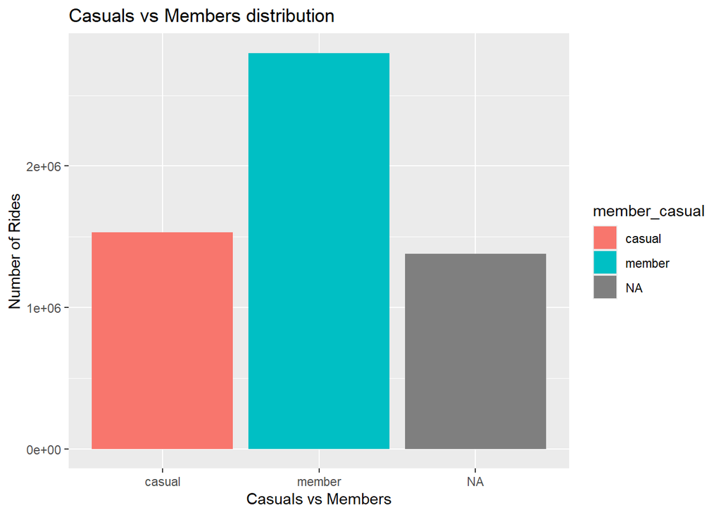

```r
## Casual vs member riders’ distribution (visualization)

ggplot(tripdata23_cln5, aes(x=member_casual,fill = member_casual)) + geom_bar() + labs(x="Casuals vs Members",y="Number of Rides",title = "Casuals vs Members distribution")
```

Comparison between Members Causal riders depending on ride length (mean, median, minimum, maximum)

```r
tripdata23_cln5 %>% group_by(member_casual) %>% summarise(average_ride_length=mean(ride_length),median_length=median(ride_length),max_ride_length=max(ride_length),min_ride_length=min(ride_length))
```

```
## # A tibble: 3 × 5
##   member_casual average_ride_length median_length max_ride_length
##   <chr>                       <dbl>         <dbl>           <dbl>
## 1 casual                      1376.           765          728178
## 2 member                       728.           517           89872
## 3 <NA>                          NA             NA              NA
## # ℹ 1 more variable: min_ride_length <dbl>
```

- From the above table we can conclude that casual riders took bike for longer rides than members, as the average trip duration / average ride length of member riders is lower than the average trip duration / average ride length of casual riders.

See total rides and average ride time by each day for members vs casual riders

```r
## lets fix days of week order

tripdata23_cln5$day_of_week <- ordered(tripdata23_cln5$day_of_week,levels=c("Sunday","Monday","Tuesday","Wednesday","Thursday","Friday","Saturday"))

tripdata23_cln5 %>%
group_by(member_casual,day_of_week) %>%
summarise(number_of_rides = n(),average_ride_length=mean(ride_length),.groups = "drop") %>% arrange(member_casual,day_of_week)
```

```
## # A tibble: 15 × 4
##    member_casual day_of_week number_of_rides average_ride_length
##    <chr>         <ord>                 <int>               <dbl>
##  1 casual        Sunday               254761               1594.
##  2 casual        Monday               175401               1352.
##  3 casual        Tuesday              181537               1231.
##  4 casual        Wednesday            183092               1176.
##  5 casual        Thursday             198931               1200.
##  6 casual        Friday               227869               1339.
##  7 casual        Saturday             310166               1555.
##  8 member        Sunday               307870                817.
##  9 member        Monday               386697                693.
## 10 member        Tuesday              448850                699.
## 11 member        Wednesday            452721                695.
## 12 member        Thursday             452660                696.
## 13 member        Friday               400507                722.
## 14 member        Saturday             350645                815.
## 15 <NA>          <NA>                1381180                 NA
```

Visualize total rides data by type and day of week

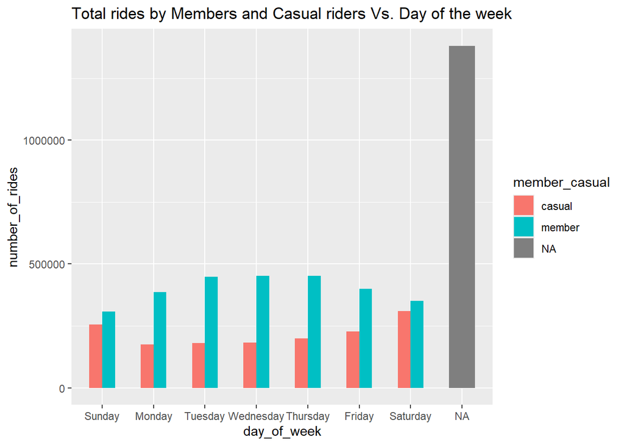

```r
tripdata23_cln5 %>%
group_by(member_casual,day_of_week) %>%
summarise(number_of_rides=n(),.groups = "drop") %>%
arrange(member_casual,day_of_week) %>% ggplot(aes(x=day_of_week,y=number_of_rides,fill=member_casual)) +
labs(title = "Total rides by Members and Casual riders Vs. Day of the week") + geom_col(width = 0.5,position = position_dodge(width = 0.5)) +
scale_y_continuous(labels = function(x) format(x,scientific=FALSE))
```

Visualize average ride time data by type and day of week

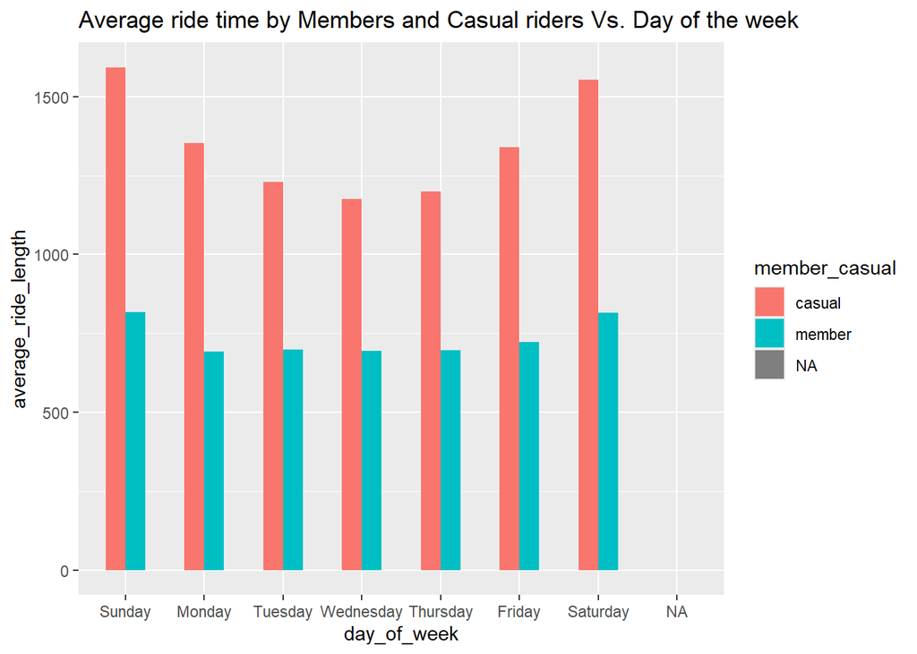

```r
tripdata23_cln5 %>%
group_by(member_casual,day_of_week) %>% summarise(average_ride_length=mean(ride_length),.groups = "drop") %>% ggplot(aes(x=day_of_week,y=average_ride_length,fill=member_casual)) +
geom_col(width = 0.5,position = position_dodge(width = 0.5)) +
labs(title = "Average ride time by Members and Casual riders Vs. Day of the week")
```

See total rides and average ride time by each month for members vs casual riders

```r
## Lets fix months of year order

tripdata23_cln5$month <- ordered(tripdata23_cln5$month,levels=c("January","February","March","April","May","June","July","August","September","October","November","December"))

tripdata23_cln5 %>%
group_by(member_casual,month) %>% summarise(number_of_rides=n(),average_ride_length=mean(ride_length),.groups = "drop") %>% arrange(member_casual,month)
```

```
## # A tibble: 25 × 4
##    member_casual month     number_of_rides average_ride_length
##    <chr>         <ord>               <int>               <dbl>
##  1 casual        January             29621                893.
##  2 casual        February            32776               1060.
##  3 casual        March               46792               1003.
##  4 casual        April              110538               1357.
##  5 casual        May                177039               1471.
##  6 casual        June               219794               1444.
##  7 casual        July               245294               1513.
##  8 casual        August             233856               1461.
##  9 casual        September          196964               1412.
## 10 casual        October            130300               1283.
## # ℹ 15 more rows
```

Visualize total rides data by type and month

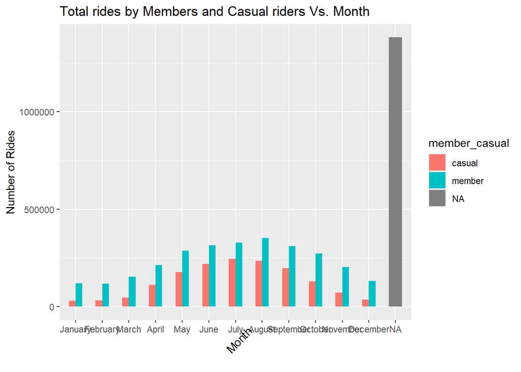

```r
tripdata23_cln5 %>%
group_by(member_casual,month) %>%
summarise(number_of_rides=n(),.groups = "drop") %>%
arrange(member_casual,month) %>% ggplot(aes(x=month,y=number_of_rides,fill=member_casual)) + labs(title = "Total rides by Members and Casual riders Vs. Month",x="Month",y="Number of Rides") +
theme(axis.title.x = element_text(angle = 45)) +
geom_col(width = 0.5,position = position_dodge(width = 0.5)) +
scale_y_continuous(labels = function(x) format(x,scientific=FALSE))
```

Visualize average ride time data by type and month

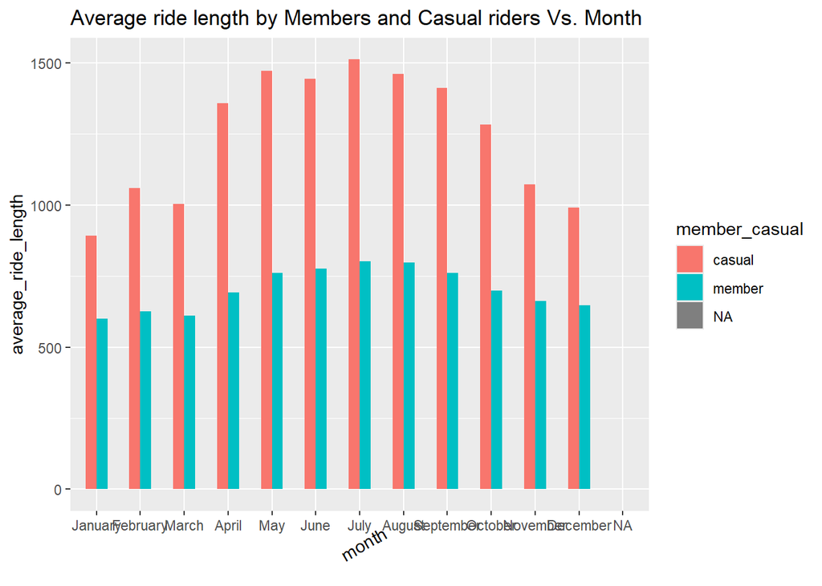

```r
tripdata23_cln5 %>%
group_by(member_casual,month) %>%
summarise(average_ride_length=mean(ride_length),.groups = "drop") %>% ggplot(aes(x=month,y=average_ride_length,fill = member_casual))+geom_col(width = 0.5,position = position_dodge(width = 0.5)) +
labs(title = "Average ride length by Members and Casual riders Vs. Month") + theme(axis.title.x = element_text(angle = 30))
```

Comparison between Members and Casual riders depending on ride distance

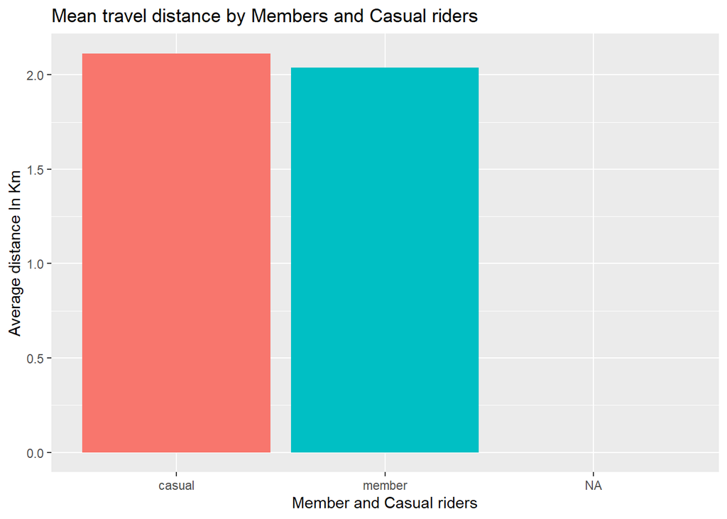

```r
tripdata23_cln5 %>% group_by(member_casual) %>% summarise(average_ride_distance=mean(ride_distance)) %>%
ggplot() + geom_col(mapping = aes(x=member_casual,y=average_ride_distance,fill = member_casual), show.legend = FALSE) +
labs(title="Mean travel distance by Members and Casual riders",x="Member and Casual riders",y="Average distance In Km")
```

- From the above chart we can see that both riders travel about the same average distance. This similarity could be possible due to that member take (same ride time) rides throughout the week, but casual riders took rides mostly in weekends with higher ride time.

Analysis and visualization on cyclistic’s bike demand by hour in a day

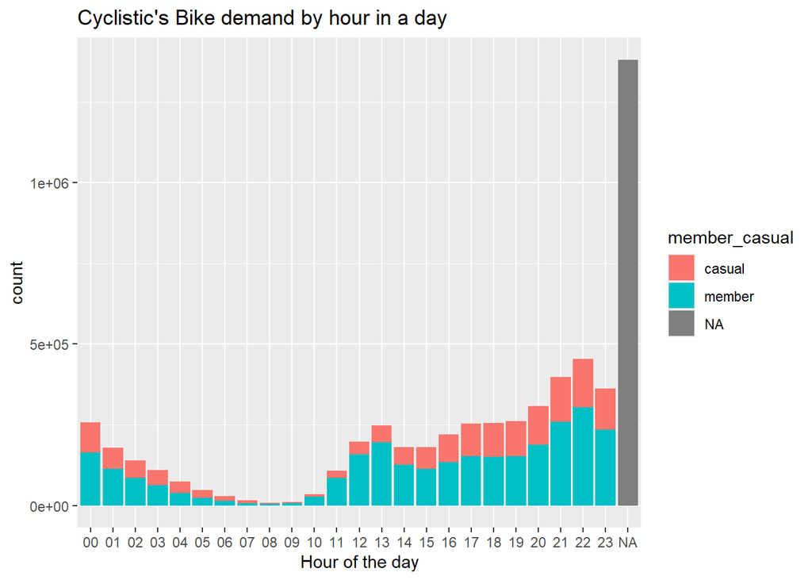

```r
tripdata23_cln5 %>% ggplot(aes(start_time,fill=member_casual)) +
labs(x="Hour of the day",title = "Cyclistic's Bike demand by hour in a day") + geom_bar()
```

Analysis and visualization on cyclistic’s bike demand per hour by day of the week

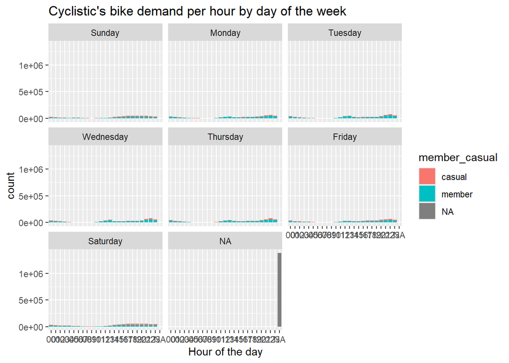

```r
tripdata23_cln5 %>% ggplot(aes(start_time,fill = member_casual)) + geom_bar() + labs(x="Hour of the day",title = "Cyclistic's bike demand per hour by day of the week") + facet_wrap(~ day_of_week)
```

Analysis and visualization of Rideable type Vs. total rides by Members and casual riders

```r
tripdata23_cln5 %>% group_by(rideable_type) %>% summarise(count = length(ride_id))
```

```
## # A tibble: 4 × 2
##   rideable_type   count
##   <chr>           <int>
## 1 classic_bike  2690744
## 2 docked_bike     76124
## 3 electric_bike 1564839
## 4 <NA>          1381180
```

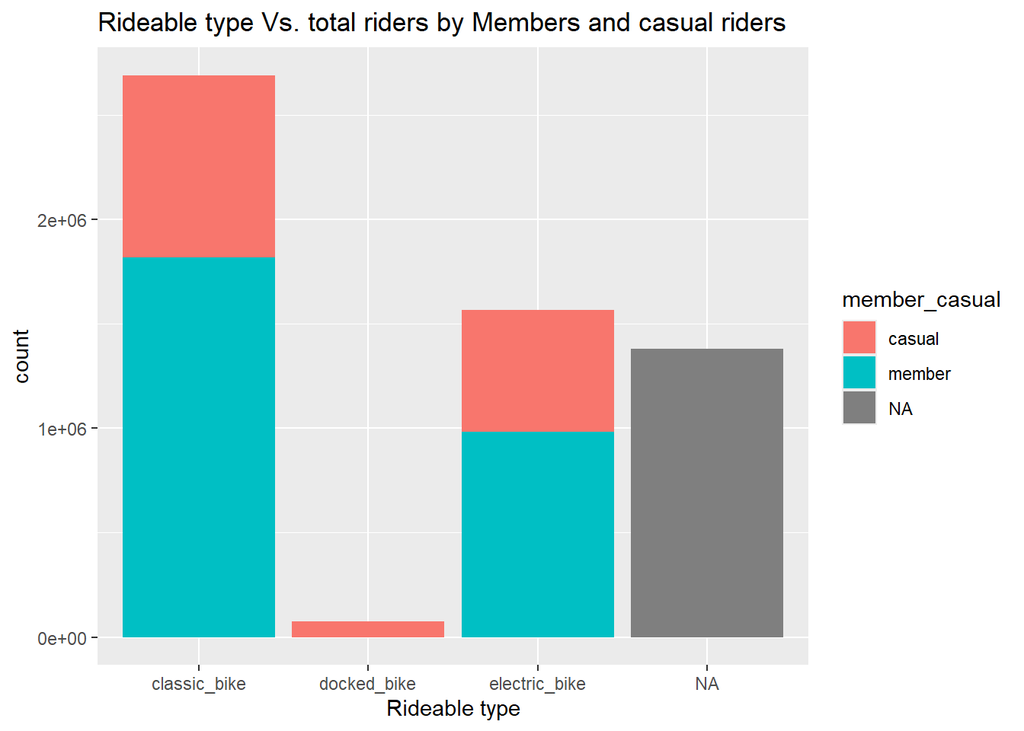

```r
ggplot(tripdata23_cln5, aes(x=rideable_type,fill = member_casual)) +
labs(x="Rideable type", title = "Rideable type Vs. total riders by Members and casual riders") + geom_bar()
```

- From the above viz we can see that members mostly use classic bikes, followed by electric bikes Docked bikes mostly used by casual riders. Electric bikes are more favored by members.

Now analyze and visualize the dataset on coordinate basis

```r
## Lets check the coordinates data of the rides.
## Adding a new data frame only for the most popular routes >200 rides

coordinates_df <- tripdata23_cln5 %>% filter(start_lng !=end_lng & start_lat !=end_lat) %>% group_by(start_lng, start_lat, end_lng, end_lat, member_casual, rideable_type) %>% summarise(total_rides = n(),.groups = "drop") %>% filter(total_rides>200)

# now lets create two different data frames depending on rider type (member_casual)

casual_riders <- coordinates_df %>% filter(member_casual=="casual")
member_riders <- coordinates_df %>% filter(member_casual=="member")
```

Lets setup ggmap and store map of Chicago (bbox, stamen map)

```r
chicago <- c(left = -87.700424, bottom = 41.790769, right = -87.554855, top = 41.990119)
```

Visualization on the map

```r
## Registered on website of Stadiamap and received API key:

register_stadiamaps(key = "d031d9b2-74eb-4a34-9889-ec5d366984ab",write = FALSE)
stadiamaps_key()
```

```
## [1] "d031d9b2-74eb-4a34-9889-ec5d366984ab"
```

```r
has_stadiamaps_key()
```

```
## [1] TRUE
```

```r
chicago_map <- get_stadiamap(bbox = chicago, zoom = 12, maptype = "stamen_terrain")
```

```
## ℹ © Stadia Maps © Stamen Design © OpenMapTiles © OpenStreetMap contributors.
```

[output not shown]

[figure not shown]

```r
## Maps on casual riders

ggmap(chicago_map,darken = c(0.1,"white")) + geom_point(casual_riders,mapping = aes(x=start_lng,y=start_lat,color=rideable_type),size=2) + coord_fixed(0.8) + labs(title = "Most used routes by Casual riders",x=NULL,y=NULL) + theme(legend.position = "none")
```

[output not shown]

```
## Warning: Removed 46 rows containing missing values or values outside the scale range
## (`geom_point()`).
```

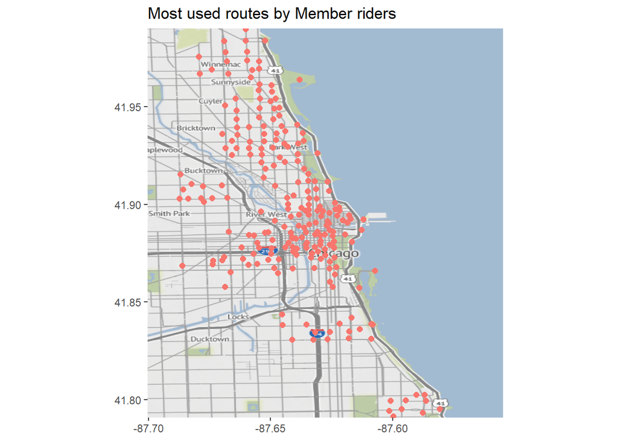

```r
## Maps on member riders

ggmap(chicago_map,darken = c(0.1,"white")) + geom_point(member_riders,mapping = aes(x=start_lng,y=start_lat,color=rideable_type),size=2) + coord_fixed(0.8) + labs(title = "Most used routes by Member riders",x=NULL,y=NULL) + theme(legend.position = "none")
```

- We can clearly see the casual rides are mostly located around the center of the town (or the bay area), with all their trips located around that area points towards their bike usage pattern, which is for leisure, probably tourist or sightseeing related rides.
- Members are mostly use bike all over the city including main city area and outside main center. This can be hypothesize as they travel for work purpose.

##Share

**Key tasks**

- Determine the best way to share your findings.
- Create effective data visualizations.
- Present your findings.
- Ensure your work is accessible.

**Deliverable**

- Supporting visualizations and key findings

**Main insights and finding conclusions**

This could be possible that member use bikes for work purpose, this information can be backed by their bike usage in colder months, where there is significant drop in casual members in those months.

##Act

Act phase will be done by the Cyclistic’s executive team, Director of Marketing (Lily Moreno), Marketing Analytics team on the basis of my analysis. (Data-driven decision making)

**Deliverable**

Top three recommendations based on your analysis

- Offer a weekend-only membership at a different price point than the full annual membership.
- Coupons and discounts could be handed out along with the annual subscription / weekend-only membership for the usage of electric bikes targeting casual riders. Also increasing the number of electric bike while reducing classic bikes if electric bike costs more for the pass, this can be beneficial for the company. (As electric bike are already in trend and usage is good as per member and ride type data.
- Create marketing campaigns which can be sent via email, or advertisement in the docking stations explaining why annual member is beneficial. Campaigns should be placed at the peak months of the year.

**Note : All ride ids are unique so we cannot conclude if the same rider taken several rides. More rider data needed for further analysis**

Additonal data that could expand scope of analysis

- Pricing details for members and casual riders - Based on this data, we might be to optimize cost structure for casual riders or provide discounts without affecting the profit margin.
- Address/ neighborhood details of members to investigate if there are any location specific parameters that encourage membership.
- Way to determine a recurring bike user using payment information or any personal identification.